# Workaround to Linking RStudio and Github

Many students face difficulties in linking RStudio and Github. This post shows a workaround using Github Desktop application.

Ashwin Malshe (University of Texas at San Antonio)https://business.utsa.edu/faculty/ashwin-malshe/  
2023-08-25

For this to work, you must have installed R and RStudio on your computer. Furthermore, you must have a Github.com account. I assume that you already created a repository on Github.com. All the screenshots in this post are taken on a laptop running Windows 10.

## Step 1

Download Github Desktop from https://desktop.github.com

[figure not shown]

```r
knitr::include_graphics(here::here("Images", "github desktop" ,"Download Github desktop.png"))
```

## Step 2

Launch Github Desktop and login using your Github credentials.

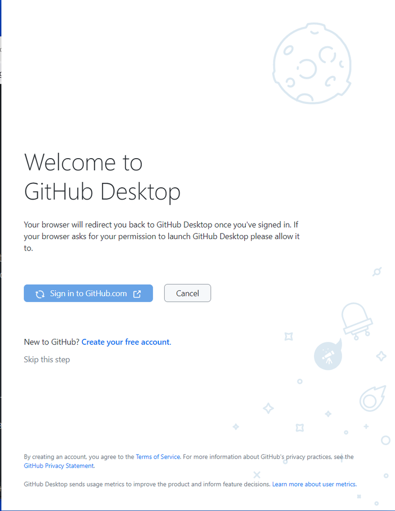

```r
knitr::include_graphics(here::here("Images", "github desktop" ,"Log in to Github desktop.png"))
```

## Step 4

Authorize Github Desktop from Github.com opened in your browser.

[figure not shown]

```r
knitr::include_graphics(here::here("Images", "github desktop" ,"Authorize the application.png"))
```

## Step 5

Go back to Github Desktop. You will see the following welcome screen. Select the second option.

[figure not shown]

```r
knitr::include_graphics(here::here("Images", "github desktop" ,"Welcome screen on Github desktop.png"))
```

## Step 6

Select the repo to clone. Also set the path where this repo will be cloned on your computer. I suggest creating a folder structure such as “MSDA/Fall 2023/Data Visualization” and then point Github Desktop to this directly. This way, the DA6233-2023 folder will get added to this directory.

[figure not shown]

```r
knitr::include_graphics(here::here("Images", "github desktop" ,"Select the repo to clone.png"))
```

After successful repo cloning you should see a similar windows:

[figure not shown]

```r
knitr::include_graphics(here::here("Images", "github desktop" ,"After the repo is cloned.png"))
```

## Step 7

Finally, open RStudio and create a new project from File > New Project. Select the second option labeled “Existing Directory”. This is because we will use the same directory that we pointed Github Desktop to in Step 6.

[figure not shown]

```r
knitr::include_graphics(here::here("Images", "github desktop" ,"Create a new project.png"))
```

Provide the full link to the project directory and click “Create Project.” That’s it!

[figure not shown]

```r
knitr::include_graphics(here::here("Images", "github desktop" ,"Navigate to the existing directory.png"))
```